# An Introduction to R for Health Policy Researchers

James Henderson

3/9/2017

## Welcome

I look forward to working with you all at the IHPI Methods Seminar, **Friday March 10, 10am-12noon**. To maximize our time during the workshop, please prepare using the checklist below.

## Checklist

1. Download and install R: https://cran.mtu.edu/
2. Download and install RStudio: https://www.rstudio.com/products/rstudio/download/
3. Download data for seminar examples: https://www.healthdata.gov/dataset/community-health-status-indicators-chsi-combat-obesity-heart-disease-and-cancer
4. Create an ‘Rworkshop’ folder on your desktop and move the data to that folder.
5. Open RStudio and set the working directory to the ‘Rworkshop’ folder you just created.
6. Download the workshop files (right click to save):
   - Methods-Seminar-10March2017.R
   - Analysis-and-Graphics.R
   - Optionally:
     - Presentation source file
     - ggplot2-primer.R

## Download and Install R

1. Visit: https://cran.mtu.edu/

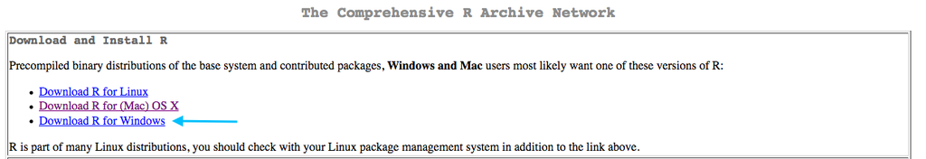

2. Choose the download appropriate for your computer.
3. Windows users should install the R binary by clicking ‘install R for the first time’.

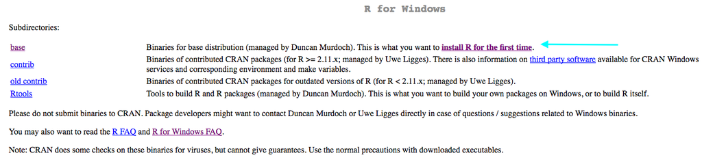

4. A link to the download and installation instructions are on the next page.

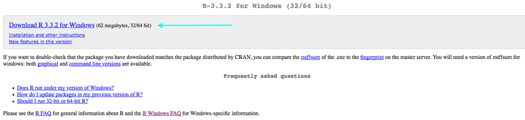

## Download and Install RStudio

We will use RStudio in the workshop. While R comes with its own graphical user interface, the RStudio interface provides additional functionality and simplifies many tasks. Make sure you install R **before** installing RStudio!

1. Visit: https://www.rstudio.com/products/rstudio/download/
2. You want to install the free RStudio Desktop

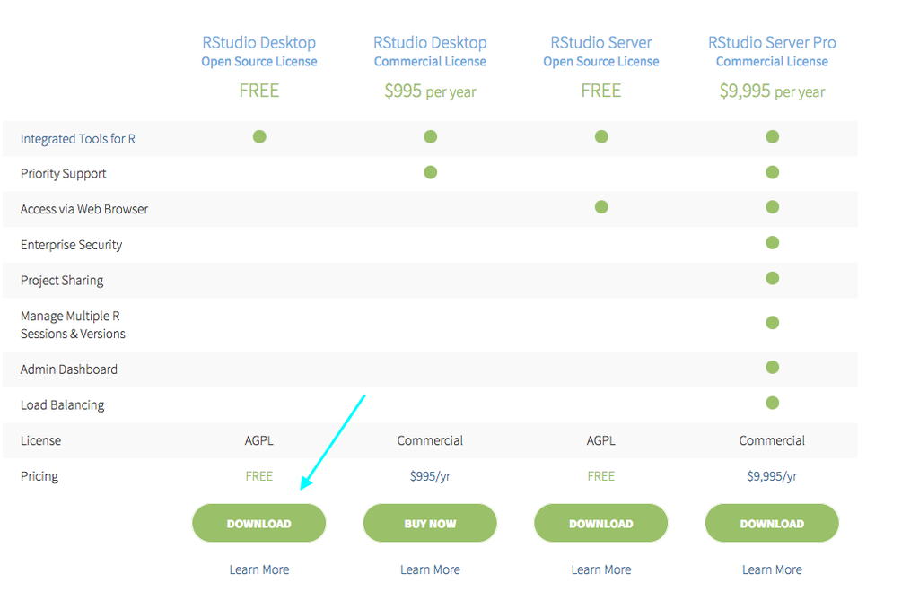

3. Download the appropriate installer and follow the prompts.

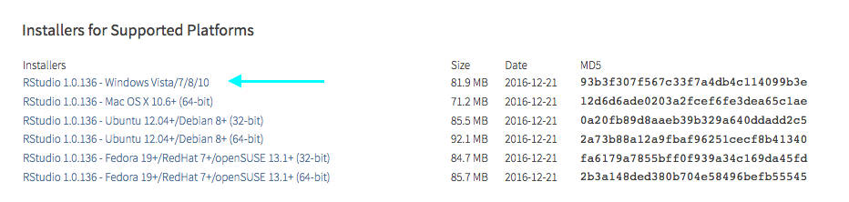

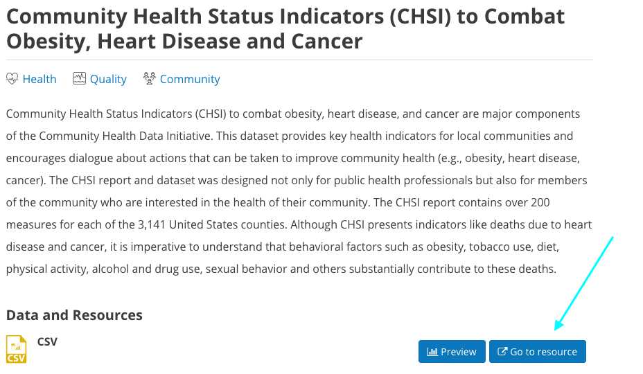

Make sure to unzip the download, you should see a folder ‘chsi_dataset’.

## Create ‘Rworkshop’ folder

Please Create a new folder ‘Rworkshop’ on your *desktop* and move the ‘chis_dataset’ folder to this location.

## Set working directory

We will use the ‘Rworkshop’ folder as the working directory for reading and writing files. We will review this at the start of the workshop, but it would be useful to do in advance.

1. Open RStudio - the appearance may differ somewhat from the screenshot.

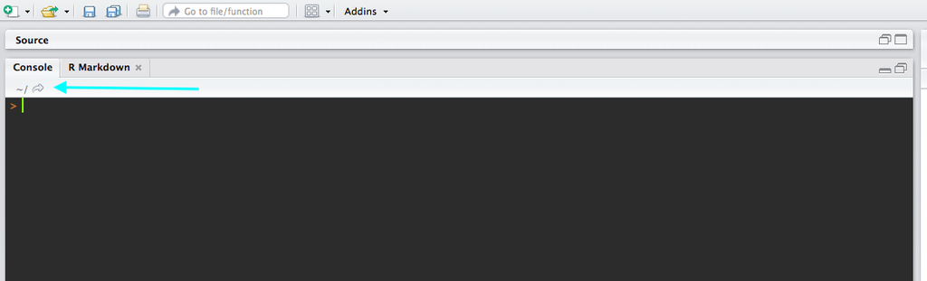

The arrow shows the current working directory.

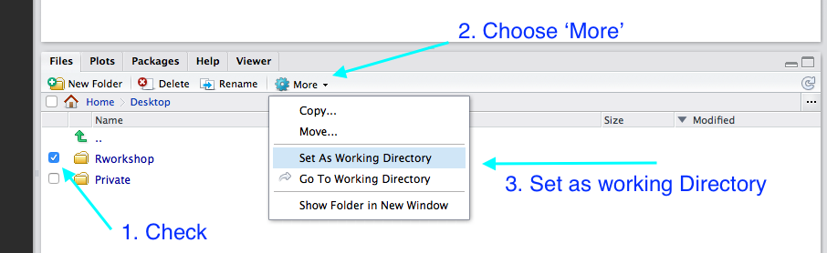

5. Check that you were successful by typing `getwd()` in the console to the left. You should see the full path to the ‘Rworkshop’ folder.

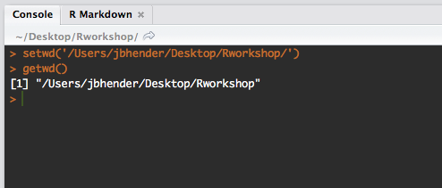

## Links to workshop files

Please download the two R scripts below:

- Methods-Seminar-10March2017.R
- Analysis-and-Graphics.R
- Optionally:
  - Slides
  - Presentation source file
  - ggplot2-primer.R

### You’re all set – see you Friday!!